# Part II - Explanatory Data Analysis of Prosper Loan Dataset

## by Henry Ime Mbom

## Investigation Overview

> In this investigation, I examined how some key features in the Prosper Loan dataset affects the Borrower's interest rate and Borrower's Annual Percentage Rate (APR)- which are the variables of interest. The variables that supported this investigation include: CreditGrade,AvailableBankcardCredit, StatedMonthlyIncome, MonthlyLoanPayment,EmploymentStatus , Occupation and LoanStatus.

## Dataset Overview

> This dataset contains the customer's data from a loan company known as Prosper. This dataset comprises of 113,937 observation with 81 Features on each loan which includes loan amount, borrower rate, current loan status, borrower income, Prosper score, etc. A detailed description of the dataset can be found in a link given in the READme file.

## Distribution of variables of interest.

> Both variables are unimodal in nature.initially the count of BorrowerAPR values between 0.00 and 0.05 appears to be nearly zero when plotted on a histogram compared to the count of BorrowerRate which is above 10000 in this range.Transforming the count axis of BorrowerAPR variable to a log scale reveals more about the count of BorrowerAPR in the range 0.00 to 0.05. In addition, BorrowerAPR variable was observed to contain 25 missing value programmatically.

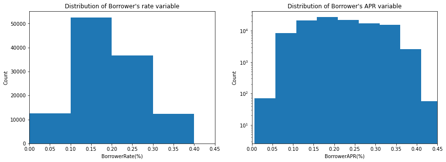

## Distribution of ProsperScore Variable

> The ProsperScore with the highest frequency is 4.0 which is less than half of the best score(10.0). The least frequency ProsperScore is 1.0. ProsperScore of 11.0 suggests an unusual value or an outlier since the ProsperScore lie between 0.0 to 10.0 based on the data description

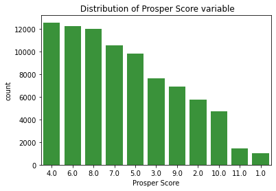

## Distribution of Stated Monthly Income.

> The histogram plot of the original data is highly driven to the left of the axis.Using summary statistics I figured out the maximum count value to be 1750000, which could have caused an outlier or error in the plot. So I created a second visualization where the top 1% of the data were dropped from the original dataset and obtained a more reasonable plot.

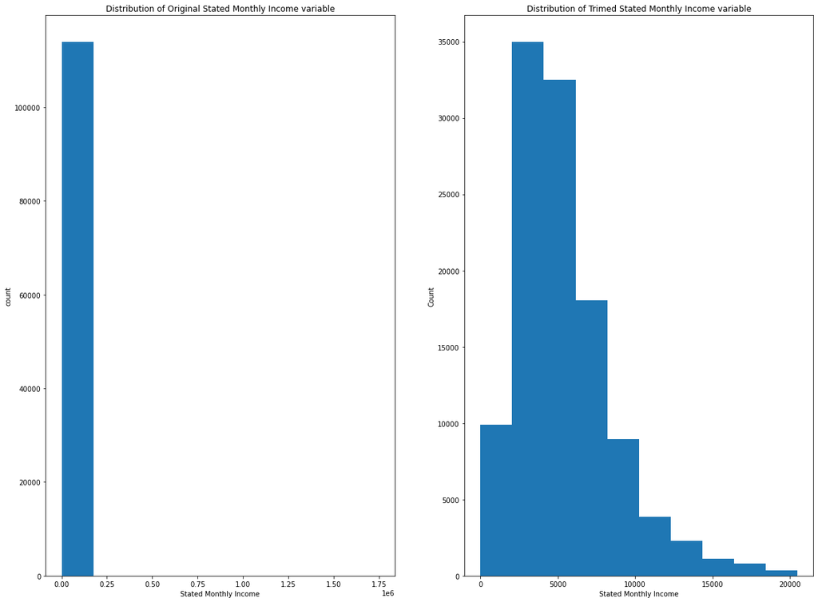

## Distribution of Employment Status variable.

> The number of Employed borrowers in the dataset is above 60000. This is reseasonable as it comprises of Full-time, self employed , part time and other category. The full time borrowers are more than the self employed borrowers; with the least being the part time borrowers. The numbers of umemployed and retired borrowrs however are very minimal.

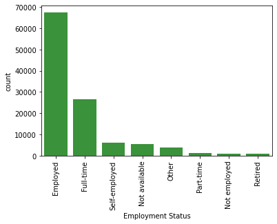

## Borrower's rate VS Borrower's APR.

> I used a heat map to show the relationship between Borrower's rate and APR. For both varaibles, the number of datapoint counts is highest where both variable intersect in the range 0.1 to 0.2. This shows great correlation in this between the variables in this range.

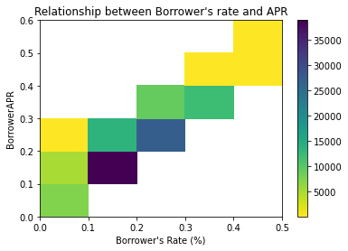

## Prosper score vs Borrower's rate.

> The plot shows strong correlation between the prosper rating with the borrower’s rate. On a general note, the borrower rate is highly correlated for Prosper's score between 3.0 and 8.0. From 8.0 to 11.0, the borrower's rate decreases.

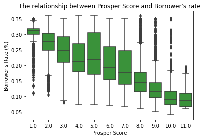

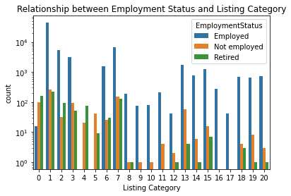

### Borrower's rate VS Available Bank card credit by Employment status.

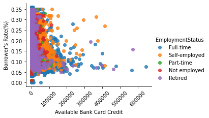

[output not shown]